# FINAL PROJECT

[figure not shown]

Has the World Become a Better Place?

By Joey Hayden

**INTRODUCTION**

As the world entered the 21st century, technology and online media has slowly come to dominate our lives. Every day we are bombarded by news of wars, terrorism, domestic inequality, corruption, homocides, and political instability. However, many others, such as Steven Pinker have proposed that despite the bleak image that the media has painted, the world at large has in fact been improving over the last few centuries, and most drastically in the last few decades. This makes us ask, which view is correct? Has the world improved, despite the many horrors we regularly hear of in the news? Most of has have heard of the military buildup in China, the Russian takeover of Crimea and of the domestic political violence in the US. Despite these events and the many other problems we hear of so often, have the lives of the average human on Earth improved? Or have certain countries improved as others are left in the dust? Or perhaps, is the news correct and the world is headed in a downward spiral? Using a number of data sets from various 3rd party organizations, I will attempt to shed some light on whether or not the world at large has improved for the average citizen with various measures from economic stability and freedom to happiness, poverty, homocides rates and other statistical measures.

# How Do You Measure Human Progress?

If we want to determine if the world has become a better place through data, we first need to figure out what we need to look for. I have decided a 6 different values, some of them are index's representing a number of different measures, while others are independent measurements. For example, the Economic Freedom Summary Index is created based on 12 different measures of economic freedom, whereas the Homocide rate is a single measurement. Below, I have listed each of the values I will be using for this analysis, along with what they represent.

## List of Values Used to Judge Human Progress

- Development Index
- Homocide Rate
- Hunger Index
- Cantril Happiness Scale
- Gender Pay Gap Comparison
- Economic Freedom Index

# Development Index

The Development Index uses life expectancy, access to education, and standard of living to generate an index value representing the total development of the culture, government, and average life of a citizen.

# Homocide Rate

The Homocide Rate is the number of homocides per 100,000 individuals in the country. It is a rate, not a number, hence it scales with the size of the country in question.

# Hunger Index

The Hunger Index measures how well the caloric and nutritional requirements are met in a specific country to generate a value. The difference between nutrition and caloric requirements are an important thing to note. An individual could have more than enough calories to survive, but lack necessary vitamins and minerals leading to sickness, disease, or even death in extreme cases.

# Cantril Happiness Scale

The Cantril Happiness data is a scale where respondents are asked to rate their lives on a scale from 1-10, where 10 is the happiest, and 1 is the most depressed.

# Gender Pay Gap Comparison

The Gender Pay Gap Comparison (Equality measure) is the percent difference between the wages of men and women in various countries over time.

# Economic Freedom Index

- Rule of Law (property rights, government integrity, judicial effectiveness)
- Government Size (government spending, tax burden, fiscal health)
- Regulatory Efficiency (business freedom, labor freedom, monetary freedom)
- Open Markets (trade freedom, investment freedom, financial freedom)

Again, these are in no way 100% comprehensive, but they do provide a very good clue as to whether or not the world at large is improving. Works such as Steven Pinker's "Enlightenment Now" cover a bit more ground in terms of the breadth of statistics and measures considered, though it is not quite as heavy in the data analysis itself. As a continuation of this, one could consider every index on the website "Our World In Data", where each index is a compilation of numerous measures. This would create a summary statistic that encompasses many dozen, if not hundreds of separate measures. That is beyond the scope of this introductory tutorial on data analysis, though it is an interesting idea to consider.

# **DATA COLLECTION**

First, we need to import some essential libraries to get started. Pandas is very useful for data wrangling and curation, providing clear ways for us to manipulate and view data. Pandas can handle heterogenous data and has is a great way to get started with data analysis. Numpy provides us some mathematical functions while matplotlib will let us create plots and graphs. The cycler will allow us to cycle through colors as we create multiple lines on a single plot.

```python
import pandas as pd
import numpy as np
import matplotlib
import matplotlib.pyplot as plt
from cycler import cycler
```

Now that our libraries are imported, we can get to work. I have imported the data from a series of .csv files from the following links. The economic data is from the Fraser Institute while the rest is from Our World In Data. Our World In Data has a huge amount of data colleted across many decades including statistics on happiness, equality, war casualities, hunger, healthcare and many more. Here, I will only look at a few of these to illustrate how we can work with this data, though it will still provide us with many meaningful conclusions. This links to this data is found at the links below:

https://www.fraserinstitute.org/economic-freedom/dataset

https://ourworldindata.org/economic-inequality-by-gender

https://ourworldindata.org/homicides

https://ourworldindata.org/hunger-and-undernourishment

https://ourworldindata.org/happiness-and-life-satisfaction

https://ourworldindata.org/human-development-index

```python
#reads and imports the data from the csv file
development_data = pd.read_csv("DEVELOPMENT INDEX DATA.csv")
#renames the column for simplicity
development_data = development_data.rename(columns = {'Historical Index of Human Development (Prados de la Escosura)':
                                                     'Index of Human Development'})
development_data.head()
```

|  | Entity | Code | Year | Index of Human Development |
| --- | --- | --- | --- | --- |
| 0 | Afghanistan | AFG | 1950 | 0.04 |
| 1 | Afghanistan | AFG | 1955 | 0.05 |
| 2 | Afghanistan | AFG | 1960 | 0.06 |
| 3 | Afghanistan | AFG | 1965 | 0.07 |
| 4 | Afghanistan | AFG | 1970 | 0.09 |

```python
#reads and imports the data from the csv file
homocide_data = pd.read_csv("HOMOCIDE DATA.csv")
#renames the column for simplicity
homocide_data = homocide_data.rename(columns = {'Deaths - Interpersonal violence - Sex: Both - Age: All Ages (Rate)':
                                                     'Homocide Rate'})
homocide_data.head()
```

|  | Entity | Code | Year | Homocide Rate |
| --- | --- | --- | --- | --- |
| 0 | Afghanistan | AFG | 1990 | 12.791298 |
| 1 | Afghanistan | AFG | 1991 | 14.666324 |
| 2 | Afghanistan | AFG | 1992 | 13.721925 |
| 3 | Afghanistan | AFG | 1993 | 13.326211 |
| 4 | Afghanistan | AFG | 1994 | 14.824391 |

```python
#reads and imports the data from the csv file
hunger_data = pd.read_csv("HUNGER DATA.csv")
#renames the column for simplicity
hunger_data = hunger_data.rename(columns = {'Global Hunger Index (IFPRI (2016))':
                                                     'Hunger Index'})
hunger_data.head()
```

|  | Entity | Code | Year | Hunger Index |
| --- | --- | --- | --- | --- |
| 0 | Afghanistan | AFG | 1992 | 49.3 |
| 1 | Afghanistan | AFG | 2000 | 52.4 |
| 2 | Afghanistan | AFG | 2008 | 39.2 |
| 3 | Afghanistan | AFG | 2016 | 34.8 |
| 4 | Afghanistan | AFG | 2017 | 33.3 |

```python
#reads and imports the data from the csv file
happiness_data = pd.read_csv("HAPPINESS DATA.csv")
#renames the column for simplicity
happiness_data = happiness_data.rename(columns = {'Life satisfaction in Cantril Ladder (World Happiness Report 2019)':
                                                     'Cantril Happiness'})
happiness_data.head()
```

|  | Entity | Code | Year | Cantril Happiness |
| --- | --- | --- | --- | --- |
| 0 | Afghanistan | AFG | 2008 | 3.723590 |
| 1 | Afghanistan | AFG | 2009 | 4.401778 |
| 2 | Afghanistan | AFG | 2010 | 4.758381 |
| 3 | Afghanistan | AFG | 2011 | 3.831719 |
| 4 | Afghanistan | AFG | 2012 | 3.782938 |

```python
#reads and imports the data from the csv file
equality_data = pd.read_csv("EQUALITY DATA.csv")
#renames the column for simplicity
equality_data = equality_data.rename(columns = {'Gender wage gap (OECD 2017)':
                                                     'Gender Wage Gap'})
equality_data.head()
```

|  | Entity | Code | Year | Gender Wage Gap |
| --- | --- | --- | --- | --- |
| 0 | Australia | AUS | 1975 | 21.6 |
| 1 | Australia | AUS | 1976 | 20.8 |
| 2 | Australia | AUS | 1977 | 18.4 |
| 3 | Australia | AUS | 1978 | 19.8 |
| 4 | Australia | AUS | 1979 | 20.0 |

```python
#reads and imports the data from the csv file
econ_data = pd.read_csv("ECON DATA.csv")
econ_data.head()
```

|  | Unnamed: 0 | Unnamed: 1 | Unnamed: 2 | Unnamed: 3 | Unnamed: 4 | Unnamed: 5 | Unnamed: 6 | Unnamed: 7 | Unnamed: 8 | Unnamed: 9 | ... | Unnamed: 70 | Unnamed: 71 | Unnamed: 72 | Unnamed: 73 | Unnamed: 74 | Unnamed: 75 | Unnamed: 76 | Unnamed: 77 | Unnamed: 78 | Unnamed: 79 |
| --- | --- | --- | --- | --- | --- | --- | --- | --- | --- | --- | --- | --- | --- | --- | --- | --- | --- | --- | --- | --- | --- |
| 0 | NaN | NaN | NaN | NaN | NaN | NaN | NaN | Area 1 | NaN | NaN | ... | NaN | NaN | NaN | NaN | NaN | NaN | NaN | NaN | NaN | NaN |
| 1 | NaN | NaN | NaN | NaN | NaN | NaN | NaN | 1A | NaN | 1B | ... | NaN | NaN | NaN | NaN | NaN | NaN | NaN | NaN | NaN | NaN |
| 2 | NaN | NaN | NaN | NaN | NaN | NaN | NaN | NaN | NaN | NaN | ... | 5Cvi | NaN | NaN | NaN | NaN | NaN | NaN | NaN | NaN | NaN |
| 3 | NaN | Year | ISO_Code | Countries | Economic Freedom Summary Index | Rank | Quartile | Government consumption | data | Transfers and subsidies | ... | Tax compliance | Business regulations | Regulation | NaN | NaN | NaN | NaN | NaN | NaN | NaN |
| 4 | NaN | 2018 | ALB | Albania | 7.80 | 26 | 1 | 8.16 | 12.27 | 6.74 | ... | 7.18 | 6.71 | 7.72 | NaN | NaN | NaN | NaN | NaN | NaN | NaN |

5 rows × 80 columns

# DATA MANAGEMENT AND CURATION

```python
#gets a list of the correct column names
column_names = econ_data.loc[3]
#drops the first column
econ_data = econ_data.drop(econ_data.columns[0],  axis = 1)
#drops the first four rows
econ_data = econ_data.drop([0,1,2,3])
#renames the columns with the correct column names
econ_data = econ_data.rename(columns = column_names)
econ_data
```

|  | Year | ISO_Code | Countries | Economic Freedom Summary Index | Rank | Quartile | Government consumption | data | Transfers and subsidies | data | ... | Tax compliance | Business regulations | Regulation | NaN | NaN | NaN | NaN | NaN | NaN | NaN |
| --- | --- | --- | --- | --- | --- | --- | --- | --- | --- | --- | --- | --- | --- | --- | --- | --- | --- | --- | --- | --- | --- |
| 4 | 2018 | ALB | Albania | 7.80 | 26 | 1 | 8.16 | 12.27 | 6.74 | 12.47 | ... | 7.18 | 6.71 | 7.72 | NaN | NaN | NaN | NaN | NaN | NaN | NaN |
| 5 | 2018 | DZA | Algeria | 4.97 | 157 | 4 | 3.22 | 29.05 | 7.82 | 8.51 | ... | 7.03 | 5.95 | 5.56 | NaN | NaN | NaN | NaN | NaN | NaN | NaN |
| 6 | 2018 | AGO | Angola | 4.75 | 159 | 4 | 7.70 | 13.82 | 9.62 | 1.88 | ... | 6.78 | 5.64 | 5.39 | NaN | NaN | NaN | NaN | NaN | NaN | NaN |
| 7 | 2018 | ARG | Argentina | 5.78 | 144 | 4 | 5.94 | 19.81 | 6.31 | 14.05 | ... | 6.51 | 6.40 | 5.76 | NaN | NaN | NaN | NaN | NaN | NaN | NaN |
| 8 | 2018 | ARM | Armenia | 7.92 | 18 | 1 | 7.72 | 13.76 | 7.71 | 8.90 | ... | 7.04 | 7.28 | 7.76 | NaN | NaN | NaN | NaN | NaN | NaN | NaN |
| ... | ... | ... | ... | ... | ... | ... | ... | ... | ... | ... | ... | ... | ... | ... | ... | ... | ... | ... | ... | ... | ... |
| 4050 | 1970 | VNM | Vietnam | NaN | NaN | NaN | NaN | NaN | NaN | NaN | ... | NaN | NaN | NaN | NaN | NaN | NaN | NaN | NaN | NaN | NaN |
| 4051 | 1970 | YEM | Yemen, Rep. | NaN | NaN | NaN | NaN | NaN | NaN | NaN | ... | NaN | NaN | NaN | NaN | NaN | NaN | NaN | NaN | NaN | NaN |
| 4052 | 1970 | ZMB | Zambia | 5.27 | 54 | 3 | 3.45 | 28.28 | 9.11 | 3.78 | ... | NaN | NaN | 6.39 | NaN | NaN | NaN | NaN | NaN | NaN | NaN |
| 4053 | 1970 | ZWE | Zimbabwe | NaN | NaN | NaN | 7.81 | 13.46 | NaN | NaN | ... | NaN | NaN | NaN | NaN | NaN | NaN | NaN | NaN | NaN | NaN |
| 4054 | NaN | NaN | NaN | NaN | NaN | NaN | NaN | NaN | NaN | NaN | ... | NaN | NaN | NaN | NaN | 1.0 | NaN | NaN | NaN | NaN | NaN |

4051 rows × 79 columns

Great! Now we have cleaned up our data... sort of. If we take a look at the table we printed out, there are still a number of spaces filled with "NaN". There are three ways we could deal with this. We could:

- Remove rows and columns with missing data
- Encode missing data
- Impute missing data

Each of these has some pros and cons. For our case, we will be using the first option: Remove the missing data. Fortunately, the Economic Freedom Summary Index acts as a summary statistic for all of the other measures in our table. This means that the organization collecting the data has already done some of their own imputation to create the index when certain measures in the index are missing, such as the case in in row 4052 seen above where tax compliance and Business regulations have missing values. There will still be missing data when even the index is missing, but it is an improvement nonetheless.

```python
#Selects only the columns of the table we will be using
econ_data = econ_data[['Year', 'ISO_Code', 'Countries', "Economic Freedom Summary Index"]].dropna()
#This data set seems to have stored the year as a string. This corrects it
econ_data['Year'] = econ_data['Year'].astype(int)
#Again, I have corrected to data type to float
econ_data['Economic Freedom Summary Index'] = econ_data['Economic Freedom Summary Index'].astype(float)
econ_data
```

|  | Year | ISO_Code | Countries | Economic Freedom Summary Index |
| --- | --- | --- | --- | --- |
| 4 | 2018 | ALB | Albania | 7.80 |
| 5 | 2018 | DZA | Algeria | 4.97 |
| 6 | 2018 | AGO | Angola | 4.75 |
| 7 | 2018 | ARG | Argentina | 5.78 |
| 8 | 2018 | ARM | Armenia | 7.92 |
| ... | ... | ... | ... | ... |
| 4046 | 1970 | GBR | United Kingdom | 5.99 |
| 4047 | 1970 | USA | United States | 7.55 |
| 4048 | 1970 | URY | Uruguay | 5.84 |
| 4049 | 1970 | VEN | Venezuela, RB | 7.33 |
| 4052 | 1970 | ZMB | Zambia | 5.27 |

3407 rows × 4 columns

Now we have loaded all of our data and can start doing exploratory data analysis. We can't make any huge assumptions right at the beginning, so it is usually a good idea to start with some general plot of all of our values. If the plot ends up looking messy, or no meaningful conclusions can be drawn, then we can try a new method and experiment to find what we are looking for (assuming a correlation exists). If we do notice any patterns or interesting indications on our plots, we can focus on those sections and dive further in with our data analysis.

# EXPLORATORY DATA ANALYSIS

Time to get into the analysis. First we will create some simple scatter plots. I'll add a linear regression line as a reference, though we can't say whether the regression is a good fit without some further analysis.

```python
#creates color and linestyle cycler for graphs
default_cycler = (cycler(color=['b', 'g', 'r','y','k','m']) +
                  cycler(linestyle=['-', '--', ':', '-.','-','--']))

plt.rc('lines', linewidth=1)
plt.rc('axes', prop_cycle=default_cycler)
```

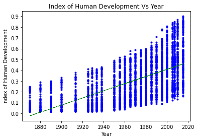

```python
#Creates x and y variables to clearly indicate independent and dependent variables
x = development_data['Year']
y = development_data['Index of Human Development']

plt.plot(x, y, linestyle = '', marker = '.')

#plots the linear regression
m, b = np.polyfit(x, y, 1)
plt.plot(x, m*x + b)

#Adds titles to the plot and axis
plt.title("Index of Human Development Vs Year")
plt.xlabel('Year')
plt.ylabel('Index of Human Development')
plt.yticks(list(np.linspace(0, max(y),10)))
plt.show()
```

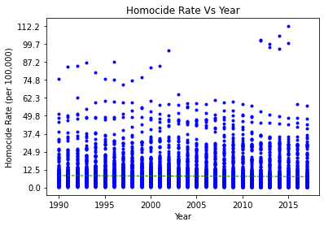

```python
#creates clear independent and dependent variables
x = homocide_data['Year']
y = homocide_data['Homocide Rate']

#plots x and y with the givne linestyle and marker
plt.plot(x, y, linestyle = '', marker = '.')

m, b = np.polyfit(x, y, 1)
plt.plot(x, m*x + b)

#gives titles to the plot and its axis
plt.title("Homocide Rate Vs Year")
plt.xlabel('Year')
plt.ylabel('Homocide Rate (per 100,000)')
plt.yticks(list(np.linspace(0, max(y),10)))
plt.show()
```

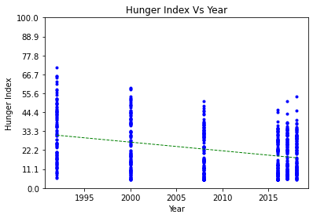

```python
#defines the indepedent and dependent variables
x = hunger_data['Year']
y = hunger_data['Hunger Index']

plt.plot(x, y, linestyle = '', marker = '.')

#plots the regression
m, b = np.polyfit(x, y, 1)
plt.plot(x, m*x + b)

#titles the plot and the axis
plt.title("Hunger Index Vs Year")
plt.xlabel('Year')
plt.ylabel('Hunger Index')
plt.yticks(list(np.linspace(0, 100,10)))
plt.show()
```

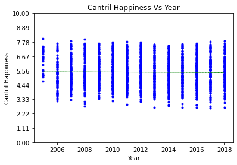

```python
#defines the independent and dependent variables
x = happiness_data['Year']
y = happiness_data['Cantril Happiness']

plt.plot(x, y, linestyle = '', marker = '.')

#creates the regression line
m, b = np.polyfit(x, y, 1)
plt.plot(x, m*x + b)

#titles the plot and the axis
plt.title("Cantril Happiness Vs Year")
plt.xlabel('Year')
plt.ylabel('Cantril Happiness')
plt.yticks(list(np.linspace(0, 10,10)))
plt.show()
```

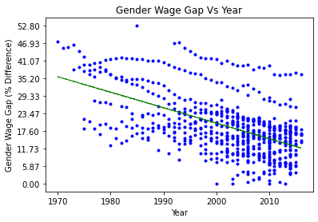

```python
#creates the indepedent and dependent variables
x = equality_data['Year']
y = equality_data['Gender Wage Gap']

plt.plot(x, y, linestyle = '', marker = '.')

#plots the regression line
m, b = np.polyfit(x, y, 1)
plt.plot(x, m*x + b)

#titles the plot and the axis
plt.title("Gender Wage Gap Vs Year")
plt.xlabel('Year')
plt.ylabel('Gender Wage Gap (% Difference)')
plt.yticks(list(np.linspace(0, max(y),10)))
plt.show()
```

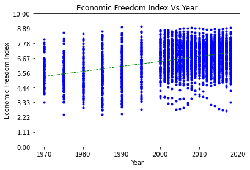

```python
#creates the independent and dependent variables
x = econ_data['Year']
y = econ_data['Economic Freedom Summary Index']

plt.plot(x, y, linestyle = '', marker = '.')

#plots the regression line
m, b = np.polyfit(x, y, 1)
plt.plot(x, m*x + b)

#titles the plot and the axis
plt.title("Economic Freedom Index Vs Year")
plt.xlabel('Year')
plt.ylabel('Economic Freedom Index')
plt.yticks(list(np.linspace(0, 10, 10)))

plt.show()
```

So, we've created some plots for each of the 6 measures we have decided to look at. However, they are rather messy, and it is difficult to draw any conclusions from what we have seen so far. The linear regressions we have created with the polyfit seems to indicate either no change, or a change for the better in most cases, but we can't say anything with certainty. This often happens when we are doing data analysis. Some type of plot or method may not give us the results we are looking for. However, the doesn't mean that we stop there. We continue to experiment and explore our data with different plots and other analysis methods. Lets think of a couple things we could do to get better information.

We could try making:

- Violin Plots
- Pie Charts
- Bar Charts
- Line Graphs
- Residual Plots
- Standardized Plots
- Mean Plots

Each of these has pros and cons which may represent a certain piece of our data better than another. For example, we saw in our scatter plots above that each year that a measurement was taken, our plot has a line of blue dots. It is very difficult to parse how many points are actually being plotted. Using a violin plot, we could better understand the distribution each year. On the other hand, we could use the pie chart to show what fraction of countries are fall within different ranges of the different index's such as the Hunger Index. There are nearly infinite ways to represent data and it is up to us to choose one that is most helpful. For this tutorial, we will pick a few as examples.

First, lets take a look at the Global Hunger Index (what I have referred to as the Hunger Index). The official scale is seen below.

GHI Severity Scale

≤ 9.9  
low

10.0–19.9  
moderate

20.0–34.9  
serious

35.0–49.9  
alarming

≥ 50.0  
extremely alarming

It seems that while 100 is the maximum value (the worst possible value), anything above 50 is still "extremely alarming". Perhaps we could break this down into a pie chart to see how many nations are within a specific category during different years.

```python
#Lists the years data was measured
hunger_data.Year.unique()
```

```
array([1992, 2000, 2008, 2016, 2017, 2018])
```

Above we have created a list of the years when the Hunger Index data was collected. To see if there has been improvement over time, lets do a comparison between the distribution of the Hunger Index in 1992 and 2018 using a pie chart. Then we will take a look at what is good and bad about deciding to use a pie chart. This last part may be one of the most important things we do. Finding out where your method fails is very important to determine how strong your conclusion is, or if it is even viable at all. As we create these pie charts, keep in mind any ways which our plot could misrepresent the data.

```python
#Selects only the data from 1992
hunger_data_1992 = hunger_data.loc[hunger_data['Year']==1992]
```

```python
#groups the data based on the hunger index ranges
tmp = hunger_data_1992.groupby(pd.cut(hunger_data_1992["Hunger Index"], [0, 10, 20, 35, 50, 100])).count()
hunger_data_grouped = pd.DataFrame(index = ['Low', 'Moderate', 'Serious', 'Alarming', 'Extremely Alarming'], columns = ['Nations Count'])
```

```python
#Renames the column to nations count and prints a table
hunger_data_grouped['Nations Count'] = list(tmp['Hunger Index'])
hunger_data_grouped
```

|  | Nations Count |
| --- | --- |
| Low | 7 |
| Moderate | 22 |
| Serious | 23 |
| Alarming | 29 |
| Extremely Alarming | 15 |

The table above shows us the number of nations that fall within the specified range.

```python
#Creates table of the hunger percentages for each category
hunger_percentages = 100*(hunger_data_grouped['Nations Count']/sum(hunger_data_grouped['Nations Count']))
hunger_percentages = pd.DataFrame(hunger_percentages)
hunger_percentages.rename(columns = {"Nations Count":"Percentage"})
```

|  | Percentage |
| --- | --- |
| Low | 7.291667 |
| Moderate | 22.916667 |
| Serious | 23.958333 |
| Alarming | 30.208333 |
| Extremely Alarming | 15.625000 |

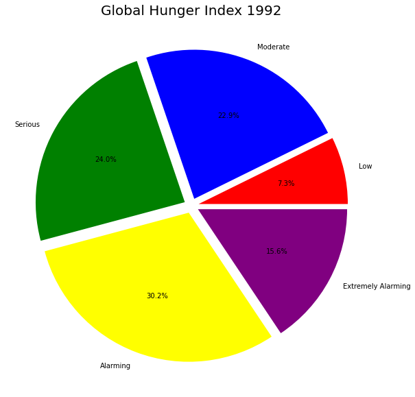

```python
#Plots the pie chart with the given categories
plt.figure(figsize=(10, 10))
plt.title('Global Hunger Index 1992', fontsize=20)
plt.pie(hunger_data_grouped['Nations Count'], explode =(0.05, 0.05, 0.05, 0.05, 0.05),
        labels=['Low', 'Moderate', 'Serious', 'Alarming', 'Extremely Alarming'],
        autopct='%1.1f%%', colors = ['red', 'blue','green','yellow','purple'])
plt.show()
```

```python
#Selects only the data from 2018
hunger_data_2018 = hunger_data.loc[hunger_data['Year']==2018]
```

```python
#groups the data based on the hunger index ranges
tmp = hunger_data_2018.groupby(pd.cut(hunger_data_2018["Hunger Index"], [0, 10, 20, 35, 50, 100])).count()
hunger_data_grouped = pd.DataFrame(index = ['Low', 'Moderate', 'Serious', 'Alarming', 'Extremely Alarming'], columns = ['Nations Count'])
```

```python
#Renames the column to nations count and prints a table
hunger_data_grouped['Nations Count'] = list(tmp['Hunger Index'])
hunger_data_grouped
```

|  | Nations Count |
| --- | --- |
| Low | 25 |
| Moderate | 27 |
| Serious | 45 |
| Alarming | 6 |
| Extremely Alarming | 1 |

The table above shows us the number of nations that fall within the specified range.

```python
#Creates hunger percentages table for the given year
hunger_percentages = 100*(hunger_data_grouped['Nations Count']/sum(hunger_data_grouped['Nations Count']))
hunger_percentages = pd.DataFrame(hunger_percentages)
hunger_percentages.rename(columns = {"Nations Count":"Percentage"})
```

|  | Percentage |
| --- | --- |
| Low | 24.038462 |
| Moderate | 25.961538 |
| Serious | 43.269231 |
| Alarming | 5.769231 |
| Extremely Alarming | 0.961538 |

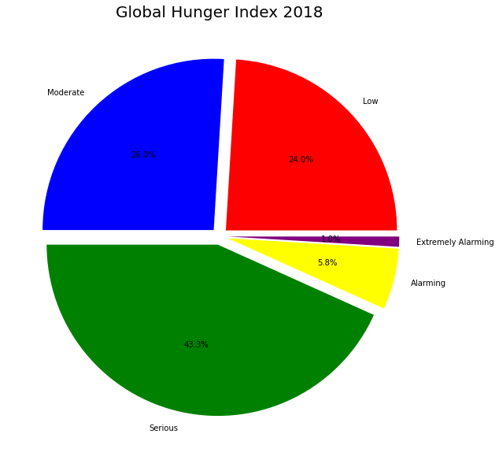

```python
#Plots given data in a pie chart
plt.figure(figsize=(10, 10))
plt.title('Global Hunger Index 2018', fontsize=20)
plt.pie(hunger_data_grouped['Nations Count'], explode =(0.05, 0.05, 0.05, 0.05, 0.05),
        labels=['Low', 'Moderate', 'Serious', 'Alarming', 'Extremely Alarming'],
        autopct='%1.1f%%', colors = ['red', 'blue','green','yellow','purple'])
plt.show()
```

Lets take a look at the plots we have created. The percentage of nations in the extremely alarming range has dropped from 15.6% to 1%. The percentage of nations in the alarming range have gone from 30% to 5.8%. On the other hand, the number of nations in the serious range has increased from 24.0% to 43.3%. In 1992, 31% of nations were in the moderate to low range, while in 2018 50% of nations were in the moderate to low hunger index range.

Overall, we can say that these charts do indicate an overall decrease in the Hunger Index, therefore indicating an an average improvement in the hunger problem across the world. Now, as good data scientists, we should pick apart what we have created to see where things could go wrong. In our case, there are actually many reasons why this plot may NOT be the best way to represent the data. I have done so in this tutorial to give an example of the problems we could run into. The other plots we create will also have a number of potential issues which we will address to help the reader develop the skills needed to avoid these problems in the future.

To list a few issues:

1. Not the same nations during the different measurements
1. In 2018, there were 8 more nations measured than in 1992. This means some of the change we see could be the addition of these nations rather than an improvement in the nations originally measured
2. Don't know the average fluctuation of Hunger Index values
1. The change that we see between the two plots could actually be due to a normal fluctuation of the Hunger Index values. What if each year different nation's Hunger Index drastically changes based on the weather during that year? And what is 1992 was simply a bad year, while 2018 was a good year?
3. Didn't calculate statistical significance
1. This is related to the previous point. If we don't calculate statistical significance, we can't say for certain whether the change we have seen is meaningful.

While these are only a couple of the problems we may run into, nonetheless, they help us to understand what to look for. Again, keep these in mind as we make more plots for the each of the different measures we are looking at.

```python
len(hunger_data_1992['Entity'].unique())
```

```
96
```

```python
len(hunger_data_2018['Entity'].unique())
```

```
104
```

Next, we will take a look at the Cantril Happiness data. Looking at our previous scatter plot, we can take a guess that a violin plot would work well for the data distribution we had there. Lets get into it.

```python
#creates list of unique years in the data
years = happiness_data['Year'].unique()

#creaets an empty array to organize data by year
happiness = []

#goes year by year and places a list for a each individual year into the happiness list
for year in years:
    happiness.append(happiness_data.loc[happiness_data['Year'] == year]['Cantril Happiness'])
```

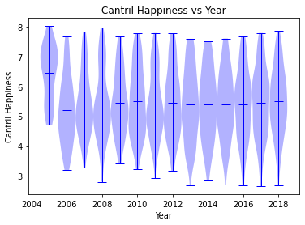

```python
plt.violinplot(happiness, years, widths=1,showmeans=True)
plt.xlabel("Year")
plt.ylabel("Cantril Happiness")
plt.title("Cantril Happiness vs Year")
```

Again, lets analyze this plot to see what we can find. We notice a couple things right at the beginning. One, the first set of data seems to be an outlier. This is likely due to which nations where given the survey during that first year. By 2006, we see a drastic change in the data compared to the previous year, which the average happiness dropping significantly. From 2006 to 2018, we see something interesting. The average happiness seems to increase just a little bit, but the shape of our distributions change more drastically. Near 2006 and 2007 we see that the distibution seems to clump near the bottom of the scale, and the distribution in 2017 and 2018 seems to be more centered. Consider ways we could improve the information we get from this plot. First we could try dropping the first year of measurement, as it seems to be a notable outlier. Then we could fit the data to a linear regression and create a residual plot. Depending on the shape of the residual plot, it could indicate the presence of an interaction between variables. Our data only has the country and the year, so we are limited in what we could test here, but in the future we could look for a different data set in order to do an analysis on the interaction. If the reader would like to look into this possible analysis more, I'd recommend the following link:

https://www.jmp.com/en_us/statistics-knowledge-portal/what-is-regression/simple-linear-regression-assumptions.html

This site helps explain how we can use residuals to analyze the effectivenessa nd validity of a linear regression. I will give an example later on, once we have created a unique plot for each of our data sets first.

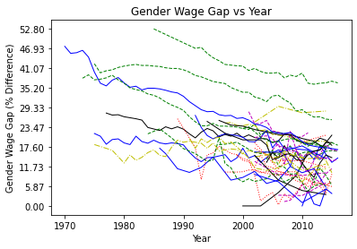

```python
#defines the characteristics of the lines
plt.rc('lines', linewidth=1)
plt.rc('axes', prop_cycle=default_cycler)

#mx is used to find the maximum y value
mx = 0
#slopes is an array of the polyfit slopes for the regression lines
slopes = []

#iterates through each country and plots the Gender Wage Gap vs Year
for Country in equality_data.Entity.unique():
    df = equality_data[equality_data['Entity'] == Country]

    x = df['Year']
    y = df['Gender Wage Gap']

    m, b = np.polyfit(x, y, 1)
    slopes.append((Country,m))

    if max(y) > mx:
        mx = max(y)

    plt.plot(x, y, marker = '', label = Country)

#Titles and labels graphs
plt.title("Gender Wage Gap vs Year")
plt.xlabel('Year')
plt.ylabel('Gender Wage Gap (% Difference)')
plt.yticks(list(np.linspace(0, mx,10)))
plt.show()
```

```python
#Creates a table of the each country in the dataset and includes the slope for the wage gap vs year
df = pd.DataFrame(slopes, columns = ['Country', 'Yearly Percent Decrease in Gender Wage Gap']).sort_values('Yearly Percent Decrease in Gender Wage Gap')
df
```

|  | Country | Yearly Percent Decrease in Gender Wage Gap |
| --- | --- | --- |
| 22 | Luxembourg | -0.955000 |
| 2 | Belgium | -0.724559 |
| 36 | United Kingdom | -0.621045 |
| 17 | Israel | -0.616364 |
| 13 | Greece | -0.610490 |
| 16 | Ireland | -0.596234 |
| 14 | Hungary | -0.588495 |
| 25 | New Zealand | -0.560672 |
| 29 | Slovakia | -0.560357 |
| 37 | United States | -0.555807 |
| 27 | Poland | -0.530559 |
| 30 | Slovenia | -0.485000 |
| 31 | South Korea | -0.463117 |
| 1 | Austria | -0.445735 |
| 19 | Japan | -0.434007 |
| 32 | Spain | -0.427500 |
| 34 | Switzerland | -0.408182 |
| 3 | Canada | -0.381404 |
| 8 | Denmark | -0.378242 |
| 12 | Germany | -0.370553 |
| 15 | Iceland | -0.336716 |
| 21 | Lithuania | -0.292500 |
| 11 | France | -0.262500 |
| 26 | Norway | -0.231404 |
| 18 | Italy | -0.226787 |
| 10 | Finland | -0.210759 |
| 0 | Australia | -0.155549 |
| 7 | Czechia | -0.108728 |
| 24 | Netherlands | -0.102500 |
| 23 | Mexico | -0.082517 |
| 33 | Sweden | -0.037386 |
| 9 | Estonia | 0.200000 |
| 20 | Latvia | 0.367500 |
| 28 | Portugal | 0.386713 |
| 35 | Turkey | 0.462500 |
| 6 | Costa Rica | 0.554286 |
| 5 | Colombia | 1.201667 |
| 4 | Chile | 1.530856 |

Another step we can take when analyzing this data is to separate view each country separately to see which nations are most in need of improvement. I will use the average Economic Freedom Summary Index from each country to demonstrate.

```python
#groups econ data by the country
c = econ_data.groupby(['Countries']).mean().reset_index().sort_values('Economic Freedom Summary Index')
```

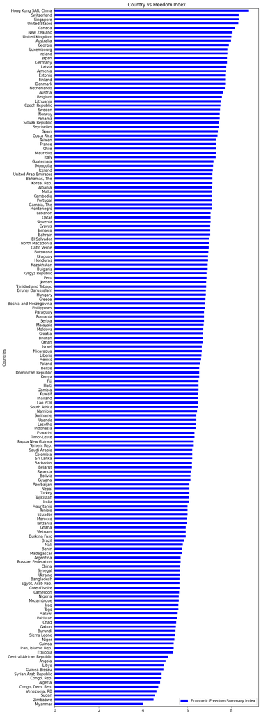

```python
#plots the average Freedom index for each ountry
ax = c.plot.barh(x='Countries', y='Economic Freedom Summary Index', figsize = (10,35), title = "Country vs Freedom Index")
```

Continuing on to our next set of data, we'll take a look at the homocide data set. Our first scatter plot of the homocide rate showed a clumping near the lower end, and a large skew toward the higher end. Lets make a violin plot to see exactly what this distribution is.

```python
#creates list of unique years in the data
years = homocide_data['Year'].unique()

#creaets an empty array to organize data by year
homocides = []

#goes year by year and places a list for a each individual year into the happiness list
for year in years:
    homocides.append(homocide_data.loc[homocide_data['Year'] == year]['Homocide Rate'])
```

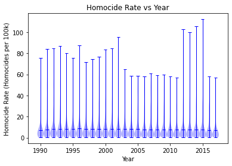

```python
plt.violinplot(homocides, years, widths=1,showmeans=True)
plt.xlabel("Year")
plt.ylabel("Homocide Rate (Homocides per 100k)")
plt.title("Homocide Rate vs Year")
```

Wow! This plot looks nothing like our previous violin plot of the Cantril Happiness Scale. We have a huge skew towards the high end, and massive clumping near the bottom. While in many cases we can try a linear regression, in this case we can say it would definitely be a bad choice. Why? It is because when making a linear regression, we make certain assumptions about the data. We assume:

- Linearity: The relationship between X and the mean of Y is linear.
- Homoscedasticity: The variance of residual is the same for any value of X.
- Independence: Observations are independent of each other.
- Normality: For any fixed value of X, Y is normally distributed.

In this case, we clearly don't have normality, a requirement for the lineear regression to be accurate. It is very difficult to determine if there has been any improvement based on this plot. Lets come back to this issue after we've completed our final plot and see if there are any tools or methods we could use in this scenario.

Finally, lets make a plot for the Human Development Index. For this one, I will make a plot of the mean Development Index value across time.

```python
development_data_grouped = development_data.groupby(['Year']).mean().reset_index()
```

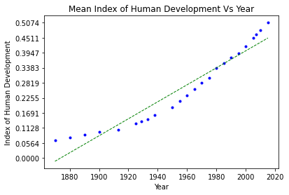

```python
#Creates x and y variables to clearly indicate independent and dependent variables
x = development_data_grouped['Year']
y = development_data_grouped['Index of Human Development']

plt.plot(x, y, linestyle = '', marker = '.')

#plots the linear regression
m, b = np.polyfit(x, y, 1)
plt.plot(x, m*x + b)

#Adds titles to the plot and axis
plt.title("Mean Index of Human Development Vs Year")
plt.xlabel('Year')
plt.ylabel('Index of Human Development')
plt.yticks(list(np.linspace(0, max(y),10)))
plt.show()
```

Again we have a very interesting plot. Our regression line once again seems to be a bad fit in this case. Our mean Development Index values are increasing in a way that seems either quadratic or exponential, which means we don't match the four requirements for a linear regression.

- Linearity: The relationship between X and the mean of Y is linear.
- Homoscedasticity: The variance of residual is the same for any value of X.
- Independence: Observations are independent of each other.
- Normality: For any fixed value of X, Y is normally distributed.

Here we fail due to non-linearity. However, in this case it is actually rather clear direction the graph is going. There is a very distinct increase of the Human Development Index across time. Looking at our original scatter plot, we also notice that the data points seem to be fairly consistent in that the points don't ever drastically vary between any two measurements, indicating a smooth change for the better.

Animesh Agarwal has a great blot on linear regression which you can read if you interested in learning more:

https://towardsdatascience.com/polynomial-regression-bbe8b9d97491

# HYPOTHESIS TESTING AND MACHINE LEARNING

We've gotten a good look at our data and now we have a good idea what we are looking for. At this point, we usually want to propose a hypothesis to test. In Hypothesis testing, we essentially have two possibilites, the Null Hypothesis and an Alternative Hypothesis. The Null Hypothesis proposes that there is no correlation between the variables. For our case, it would mean that there has been no improvement for the average human on Earth for the given time period or that any improvement that was measured is due to statistical variation and randomness. The Alternative hypothesis suggests that there is a meaningful and statistically significant correlation between the independent ande dependent variables. In our case, this means that the world has been improving meaningfully over the years in question. By performing a number of statistical methods, we can analyze with mathematical certainty whether or not the change of our vairous measures is statistically significant, or if it was due to sampling errors and randomness.

For the example in this tutorial, we will take a look at the Economic Freedom Summary Index. It is recommended that the reader try out hypothesis testing with the other data-sets to evaluate whether they agree with this example.

```python
#module to help us create the linear model
from sklearn import linear_model
```

```python
# A linear relationship between `x` and `y`.
ind = [[i] for i in econ_data['Year']]

dep = [[i] for i in econ_data['Economic Freedom Summary Index']]
```

```python
lm = linear_model.LinearRegression()
lm.fit(ind, dep)
```

```
LinearRegression()
```

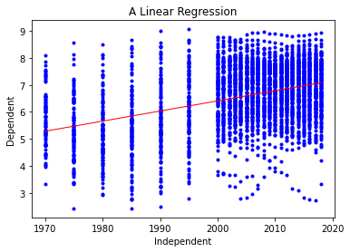

```python
fig, ax = plt.subplots()

ax.scatter(ind, dep, marker = '.')
ax.set_xlabel("Independent")
ax.set_ylabel("Dependent")
ax.set_title("A Linear Regression")

ax.plot(ind, lm.predict(ind), color='red')
```

Here, we have fit our model with scikit learn. Using the funciton lm.predict, we can predict what the value of the Economic Freedom Summary Index will be for any specified year based on the linear regression. However, lets check to see if our residuals are normal as well.

```python
#Adds a column to the econ data with the predicted value
econ_data['Prediction'] = lm.predict(ind)
```

```python
#Calculates the residuals between the prediction and the actual measured values
econ_data['residuals'] = econ_data['Economic Freedom Summary Index'] - econ_data['Prediction']
years = econ_data.Year.unique()
residuals = []

#creates a sublist with all of the residuals for the specified year
for year in years:
     residuals.append(econ_data.loc[econ_data['Year'] == year]['residuals'])
```

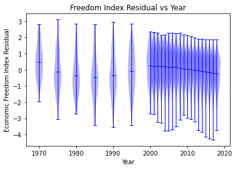

```python
fig, ax = plt.subplots()

ax.violinplot(residuals, years, widths=2,showmeans=True)
ax.set_xlabel("Year")
ax.set_ylabel("Economic Freedom Index Residual")
ax.set_title("Freedom Index Residual vs Year")
```

As we can see, there are two different sections on this graph. From 1970 to 2000, there is around a 5 year gap between each measurement. After 2000, they seem to have measured the data every single year. This makes the data from 2000 to 2010 very clustered and difficult to read. I will create a separate violin plot to show just the range from 2000-2018.

```python
#Calculates the residuals between the prediction and the actual measured values
econ_data['residuals'] = econ_data['Economic Freedom Summary Index'] - econ_data['Prediction']
years = list(range(2000, 2018))
residuals = []

#creates a sublist with all of the residuals for the specified year
for year in years:
     residuals.append(econ_data.loc[econ_data['Year'] == year]['residuals'])
```

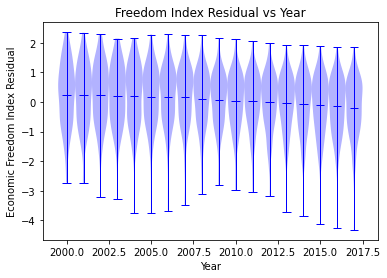

```python
fig, ax = plt.subplots()

ax.violinplot(residuals, years, widths=1,showmeans=True)
ax.set_xlabel("Year")
ax.set_ylabel("Economic Freedom Index Residual")
ax.set_title("Freedom Index Residual vs Year")
```

```python
#import module for testing our p-values
import statsmodels.api as sm
```

```python
#Creates a summary of statistical data for our prediction and original data
#We will only be looking at the coefficients and the p values here (P> |t|)
X2 = sm.add_constant(ind)
est = sm.OLS(dep, X2)
est2 = est.fit()
print(est2.summary())
```

```
                            OLS Regression Results
==============================================================================
Dep. Variable:                      y   R-squared:                       0.153
Model:                            OLS   Adj. R-squared:                  0.152
Method:                 Least Squares   F-statistic:                     613.0
Date:                Mon, 17 May 2021   Prob (F-statistic):          1.40e-124
Time:                        19:39:31   Log-Likelihood:                -5013.5
No. Observations:                3407   AIC:                         1.003e+04
Df Residuals:                    3405   BIC:                         1.004e+04
Df Model:                           1
Covariance Type:            nonrobust
==============================================================================
                 coef    std err          t      P>|t|      [0.025      0.975]
------------------------------------------------------------------------------
const        -68.3537      3.026    -22.586      0.000     -74.288     -62.420
x1             0.0374      0.002     24.759      0.000       0.034       0.040
==============================================================================
Omnibus:                       88.967   Durbin-Watson:                   1.803
Prob(Omnibus):                  0.000   Jarque-Bera (JB):               96.717
Skew:                          -0.385   Prob(JB):                     9.96e-22
Kurtosis:                       3.299   Cond. No.                     3.36e+05
==============================================================================

Notes:
[1] Standard Errors assume that the covariance matrix of the errors is correctly specified.
[2] The condition number is large, 3.36e+05. This might indicate that there are
strong multicollinearity or other numerical problems.
```

Looking at our output, we see that both our constant and our slope both have p values much less than 0.05, indicating that they are in fact statistically significant. If we had a p value greater than 0.05, it would indicate that there was not a significant different between the data and the Null Hypothesis, ie. no correlation. From this, we can confidently say that the Economic Freedom Summary Index has been increasing of the couple decades.

Since this tutorial is meant as an introduction to these topics, I won't repeat this for each of the other measures, though I do recommend the reader try it out on their own to see what they find. From this analysis, perhaps we could come up with our own index, say the Global Improvement Index which rates how much a country has improved year over year based on hunger, poverty, freedom, economic stability, political turmoil, homocides, happiness, and other factors. This tutorial just scratches the surface of what we can do and I hope that you can take this data much further than I have here.

If you'd like to get into more complex linear regressions, I'd recommend going to scikit's website:

https://scikit-learn.org/stable/modules/generated/sklearn.preprocessing.PolynomialFeatures.html

# CONCLUSION

We've reached the end! Lets go over what we did and what we've learned about data analysis. We've managed to find data sources, import them into a pandas dataframe, we cleaned them up, and then did extensive exploratory analysis creating pie charts, bar graphs, line graphs, violin plots and more. Finally we used tested our hypothesis and found a p-value to determine the significance of our alternative hypothesis.

From this, we can conclude that the world at large has generally been improving over the last few decades. Over the time frames we looked at, worldwide hunger has gone down, economic freedom has increased, the gender wage gap has decreased, and the human development index (lifespan, quality of life, etc.) has gone up. The homocide rate and cantril happiness over these periods was much more difficult to discern any change and would require further analysis to determine the significance of any fluctuations. At the very least, they did not seem to go in the wrong direction by any significant margin.

As a continuation and extension of this tutorial, the reader is encouraged to expound on the data and analysis done here. The breadth of data looked at here was extensive and there are many places where a driven data scientists could take a look into. Has the homocide rate in each individual country remained relatively constant, or have the countries with high homocide rates been changing, creating no net change on a large scale even as individual nations change greatly? What is the interaction between the gender wage gap and homocide rate? Between the economic freedom and happiness? There are many relationships and patterns which we could continue to look at. We are only limited by what we can imagine doing.

Thank you for reading! Hopefully, this tutorial has been helpful for you and inspires you to consider your own adventures into data science and the infinite possibilites it can show you.

# MORE INFO

If anyone would like to access to datasets and html code for this tutorial it can be found on my github repository at:

https://github.com/QuantumCreation/CMSC320FinalProject

Included in this repository is my completed Jupyter notebook and the csv files with the data used for this tutorial.